# Exercise 8

# Point-pattern analysis: exploring change over space

Here, we will revisit these but also look at measures that demonstrate change in distance relationships over space.

## Loading packages

```r
require("sf")
require("spatstat")
```

```r
require("ggplot2")
require("leaflet")
```

## Case study: Patterning in gorilla nest sites

```r
kawange<-c(6.120833,9.751389) #lat/long

library(leaflet)

m <- leaflet() %>%
  addTiles() %>%
  setView(kawange[2], kawange[1], zoom = 6) %>%
  addMarkers(lng=kawange[2], lat=kawange[1], popup="Kawange Gorilla Sanctuary")

m
```

[interactive chart not shown]

It’s nice to have an excuse to use `Leaflet` again, but this is also here to serve as a reminder that, despite the convention of describing locations in terms of latitude following by longitude, many R packages require coordinates in XY arrangement: that is, longitude first. If you’re ever in doubt, pull up the R help document for the function you’re calling.

## Add some data

```r
#load shapefiles for study area
studyArea<-st_read("studyArea.shp")
#import gorilla data table and convert to sf object
gorillaData<-read.csv("gorillaData.csv")
gorillaNests<-st_as_sf(gorillaData,coords=c("x","y"))

#set crs for gorilla data to same as study area
st_crs(gorillaNests)<-st_crs(studyArea)
```

We can use ggplot to see what this looks like:

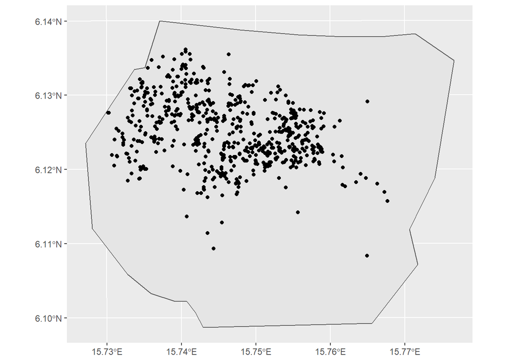

```r
g1<-ggplot() +
  geom_sf(data=studyArea) +
  geom_sf(data=gorillaNests)
print(g1)
```

And also how it looks when we map using the “season” attribute.

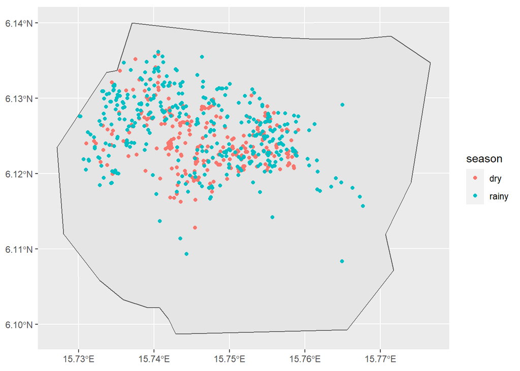

```r
g1<-ggplot() +
  geom_sf(data=studyArea) +
  geom_sf(data=gorillaNests,aes(color=season))
print(g1)
```

## Convert to point pattern

```r
gorillaPoints<-as.ppp(gorillaNests)
studyWin<- as.owin(studyArea)
gorillaPoints$window<-studyWin
```

We can get a sense of the overall character of the data using the `density` function.

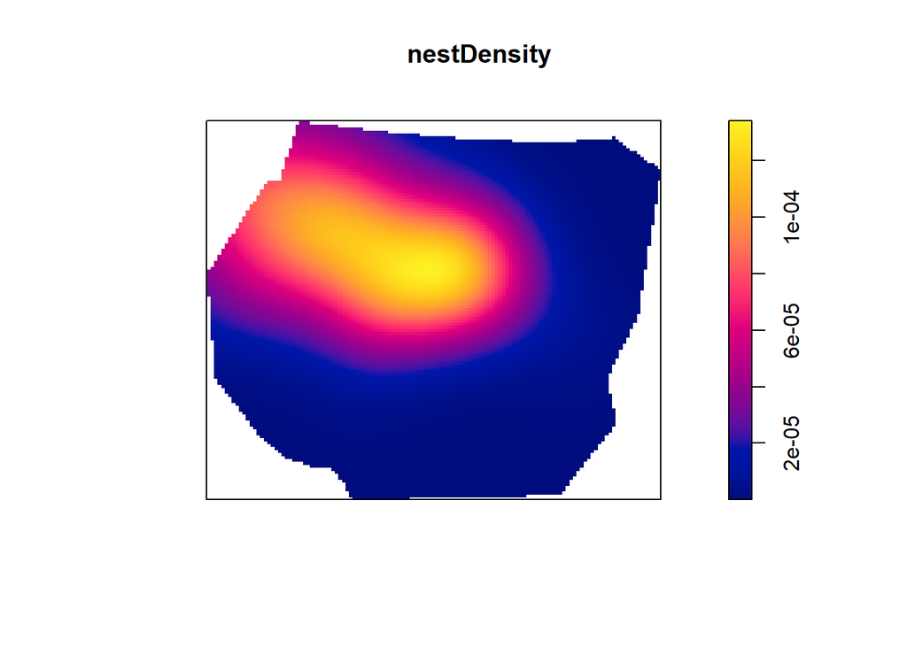

```r
nestDensity <- density(gorillaPoints,sigma=500)
plot(nestDensity)
```

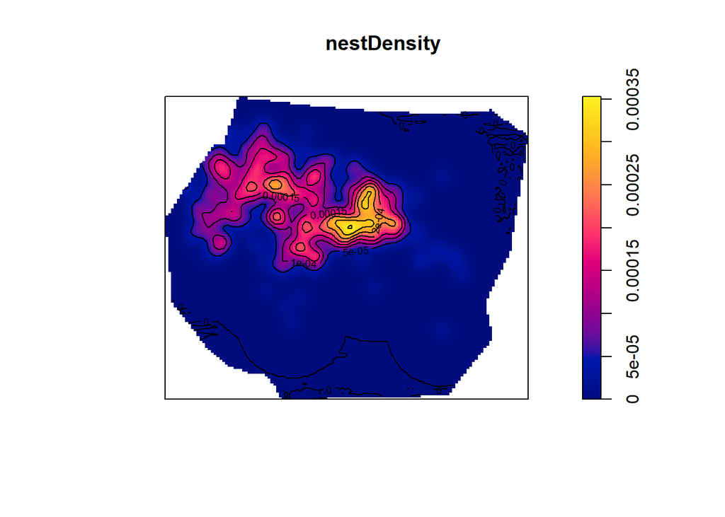

```r
nestDensity <- density(gorillaPoints,sigma=100)
plot(nestDensity)
contour(nestDensity, add=TRUE)
```

From this plot, it seems as though the nests are fairly clustered together, particularly at the middle of the sanctuary.

# Distance-based measures

Point pattern analysis can also be conducted looking at how measures change over space. These measures, classically referred to as point-pattern analysis, look at how patterns change as a function of distance from individual observations, and then summarize these over distance bands.

## Gest

This is the cumulative or “event-to-event” calculation of the nearest neighbor distance. Here, we look what proportion of points have a nearest neighbor at a given distance away. Here we will run it against a set of randomly generated points.

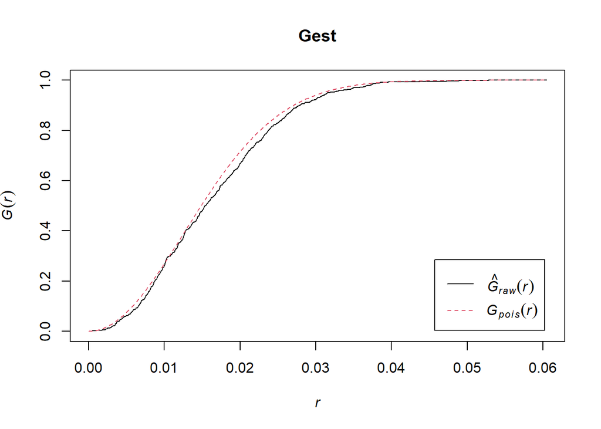

```r
x<-runif(1000,0,1)
y<-runif(1000,0,1)
xy<-data.frame(x,y)
w<-owin(c(min(x),max(x)),c(min(y),max(y)))
data<-as.ppp(xy,w)
plot(Gest(data,correction=c("none")),main="Gest")
```

The plot shows our data in black and the CSR expectation (*Gpois*) in red. Unsurprisingly, our random data follow this closely. If things were more clustered, this sigmoid pattern would shoot up more steeply at shorter distances; if it were more dispersed, it would rise at a shallower rate.

## Ripley’s *K*

From each point, Ripley’s K measures the number of other points in ever expanding radii away from that point. Then the number of points recorded at each distance for each point are averaged together. The result can be used to determine whether there is significant clustering or dispersal at different distance intervals.

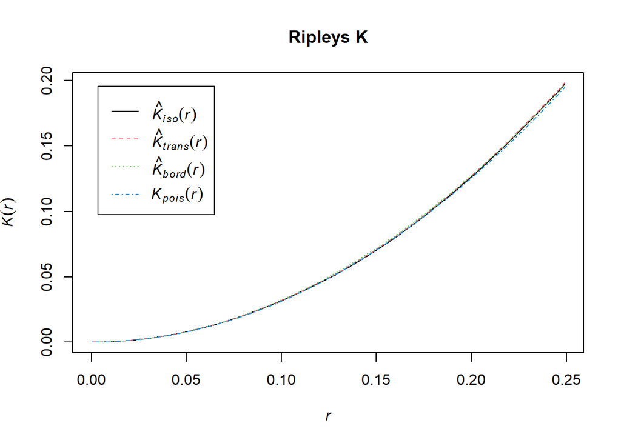

```r
x<-runif(1000,0,1)
y<-runif(1000,0,1)
xy<-data.frame(x,y)
w<-owin(c(min(x),max(x)),c(min(y),max(y)))
data<-as.ppp(xy,w)
plot(Kest(data),main="Ripleys K")
```

Once again, our random data match this pretty well. Above the line would be more clustered, below it more dispersed.

## Pairwise correlation function (PCF)

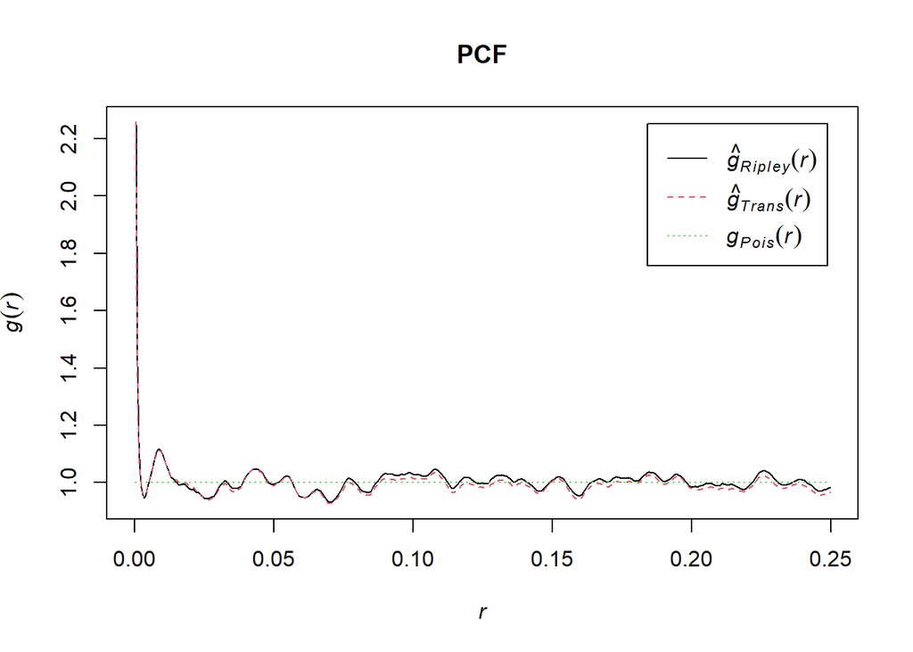

```r
x<-runif(1000,0,1)
y<-runif(1000,0,1)
xy<-data.frame(x,y)
w<-owin(c(min(x),max(x)),c(min(y),max(y)))
data<-as.ppp(xy,w)
plot(pcf(data),main="PCF")
```

## What does this look like for non-random data?

We’ve been looking at these plots using fully random data, so it isn’t surprising . The value of these plots is to see how they deviate. The spatstat package comes with some in-built datasets that we can use to illustrate these.

For example, here are three point patterns for three different tree species:

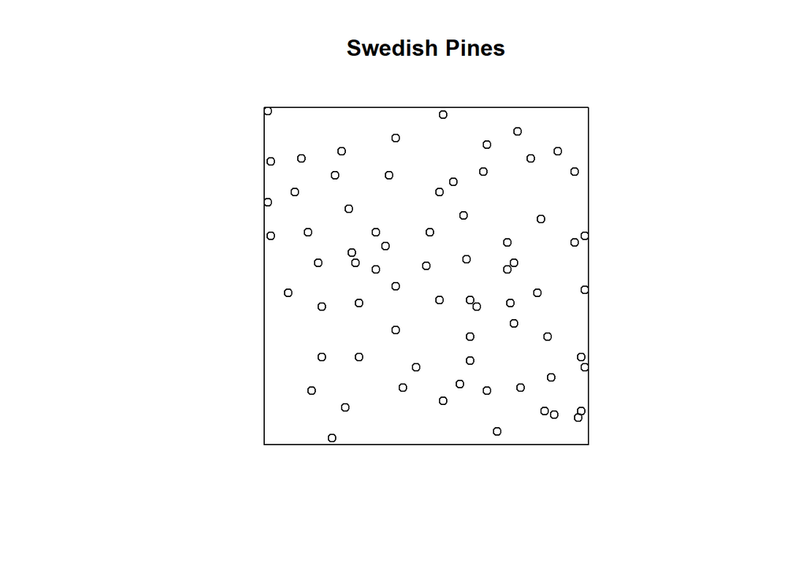

```r
plot(swedishpines,main="Swedish Pines")
```

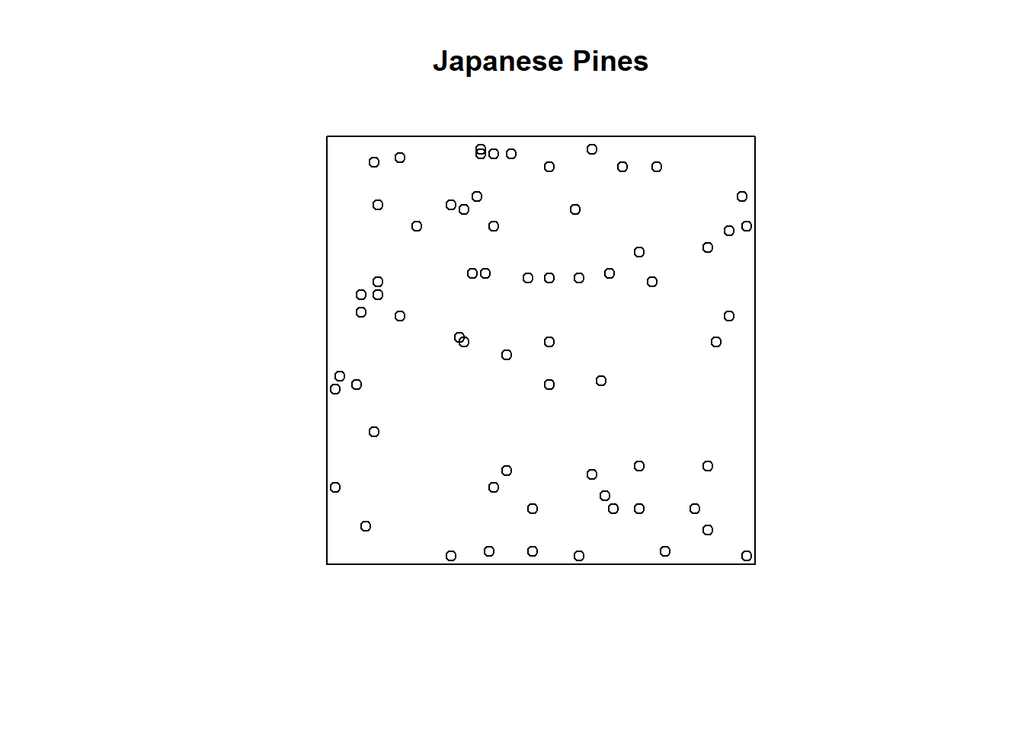

```r
plot(japanesepines,main="Japanese Pines")
```

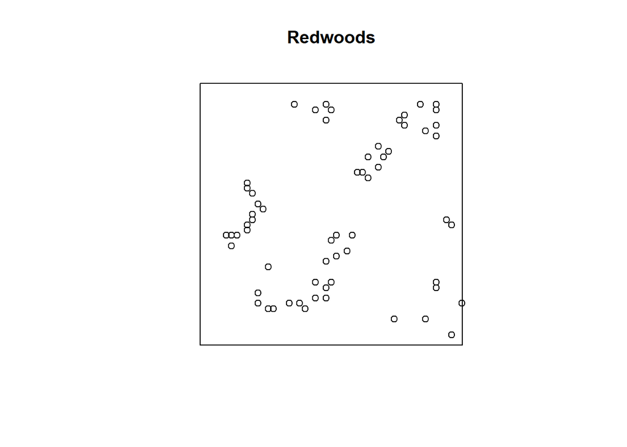

```r
plot(redwood,main="Redwoods")
```

As you can see, these are very different in terms of their relative distances. Here’s Ripley’s K for these point patterns:

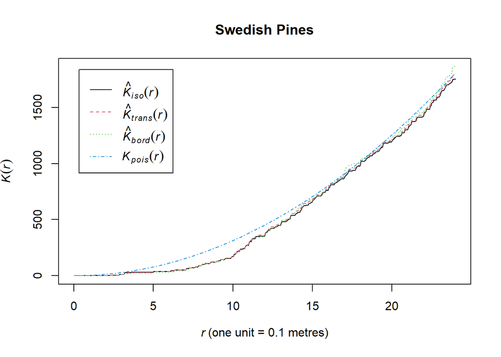

```r
plot(Kest(swedishpines),main="Swedish Pines")
```

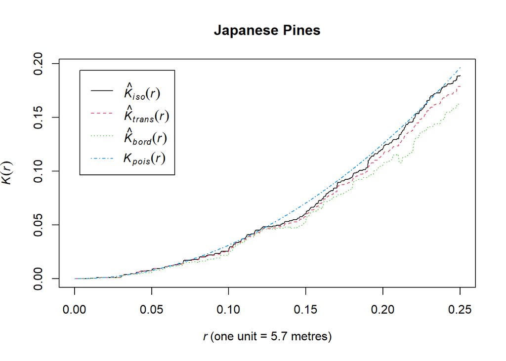

```r
plot(Kest(japanesepines),main="Japanese Pines")
```

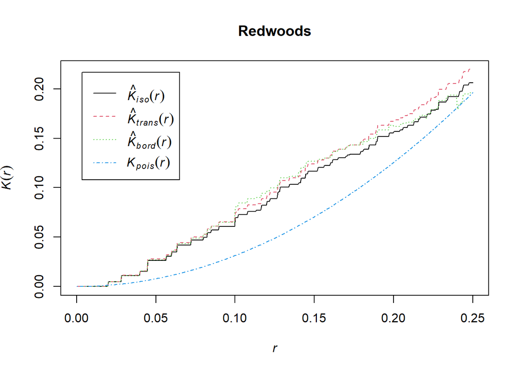

```r
plot(Kest(redwood),main="Redwoods")
```

Here’s the pairwise correlation function for a point pattern generated from an image of cells under a microscope.

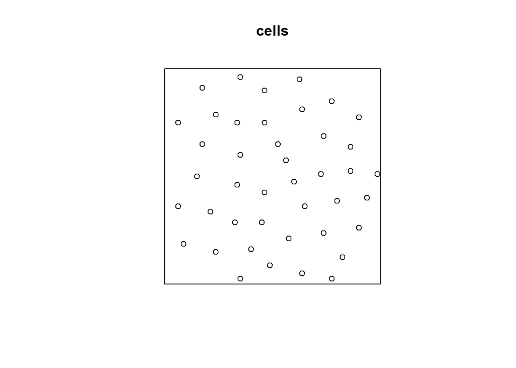

```r
plot(cells)
```

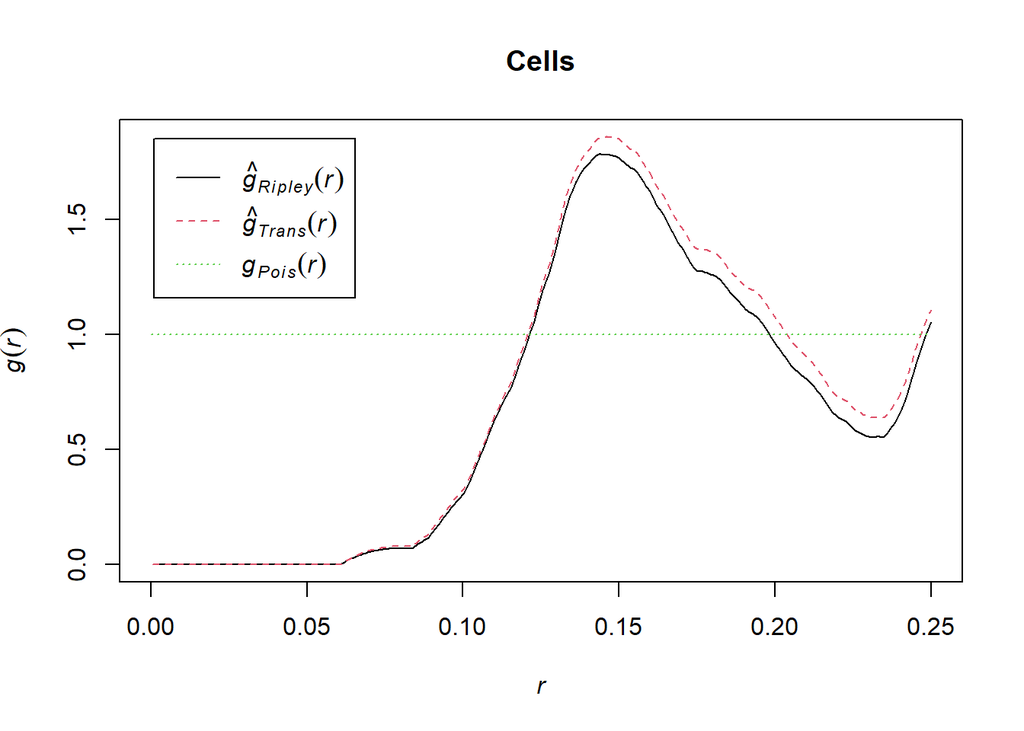

```r
plot(pcf(cells),main="Cells")
```

# Spatial patterning among gorilla nests

Now that we have seen this, we’ll run these measures using our gorilla nest dataset. First, since we’re not interested in how the marks affect these patterns, we’ll remove them.

```r
gp<-unmark(gorillaPoints)
```

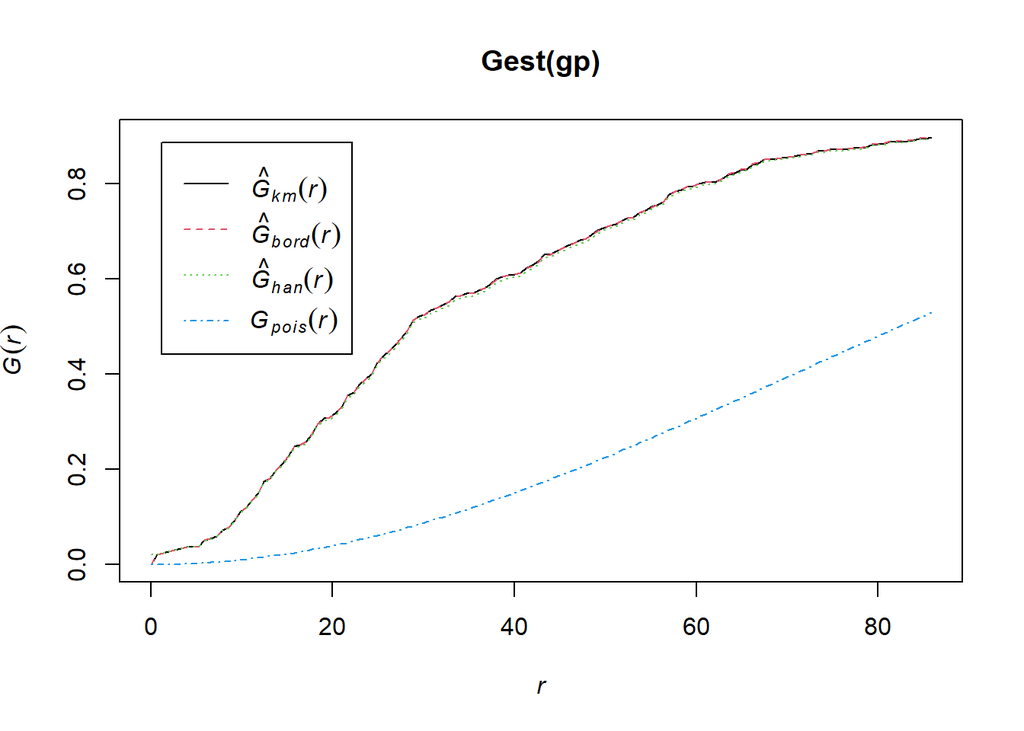

```r
plot(Gest(gp))
```

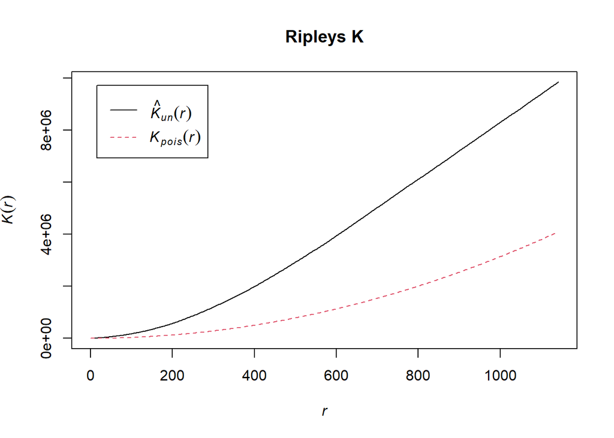

```r
plot(Kest(gp,correction=c("none")),main="Ripleys K")
```

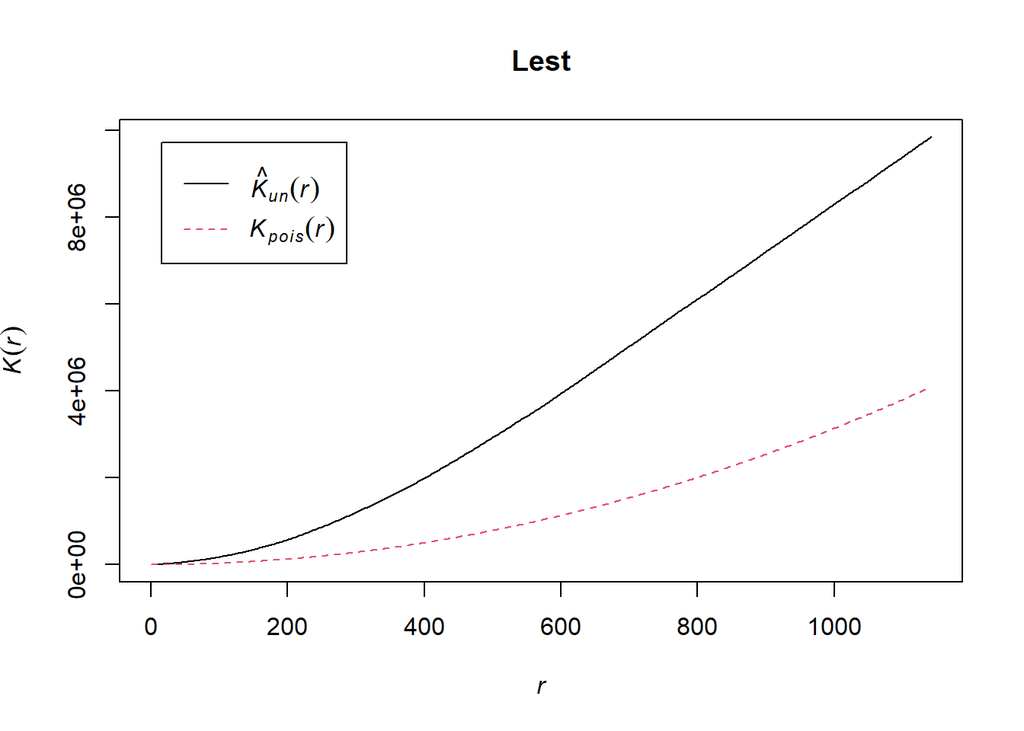

```r
plot(Kest(gp,correction=c("none")),main="Lest")
```

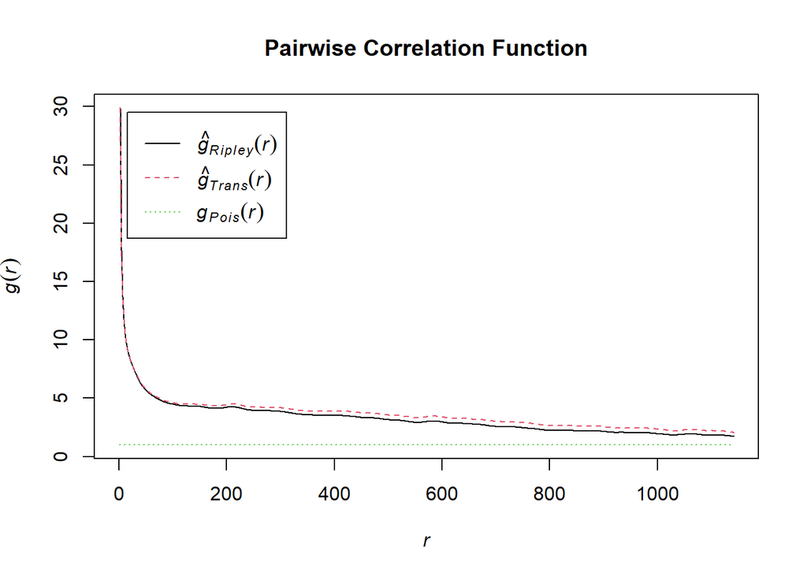

```r
plot(pcf(gp),main="Pairwise Correlation Function")
```

```r
gorillaPoints2<-as.ppp(gorillaNests)
gp2<-unmark(gorillaPoints2)
```

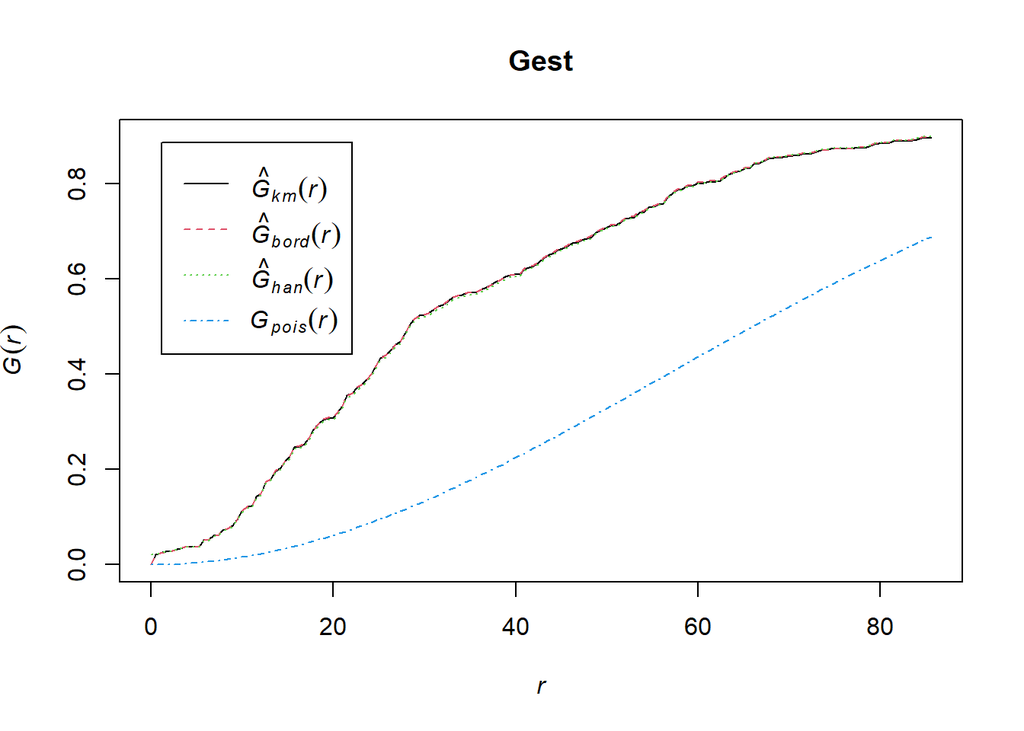

```r
plot(Gest(gp2),main="Gest")
```

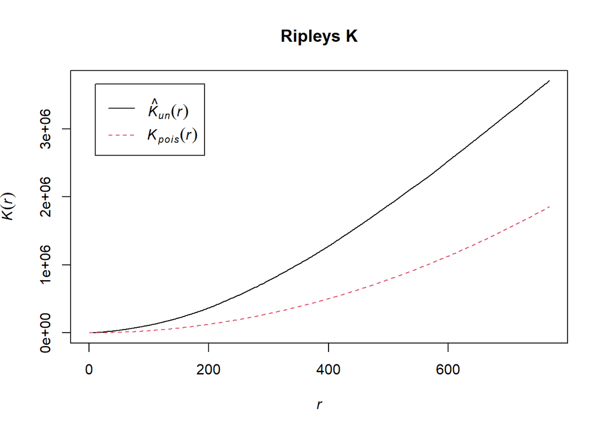

```r
plot(Kest(gp2,correction=c("none")),main="Ripleys K")
```

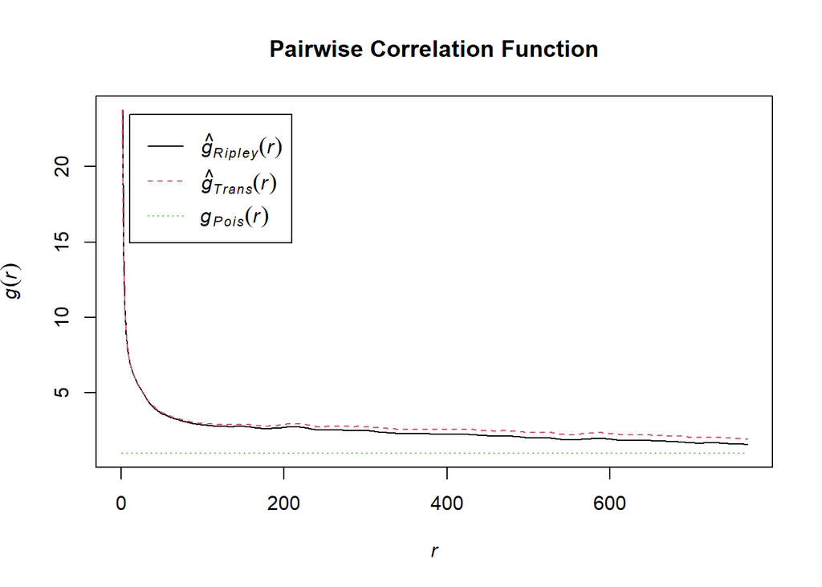

```r
plot(pcf(gp2),main="Pairwise Correlation Function")
```

# Quantifying uncertainty with simulation

While these measures help us to understand the patterning in our data, measuring against one instance of CSR is not necessarily reliable. Random processes involve a fair bit of stochasticity, and so we should expect that one random process to the next will have slightly different characteristics.

`spatstat` makes this easy (relatively speaking) with it’s `envelope` function. This repeatedly runs generates CSR patterns and calculates one of these statistics each time. Then it plots these outcomes as an envelope to compare with an empirical outcome. Here’s an example using the cells dataset and a PCF:

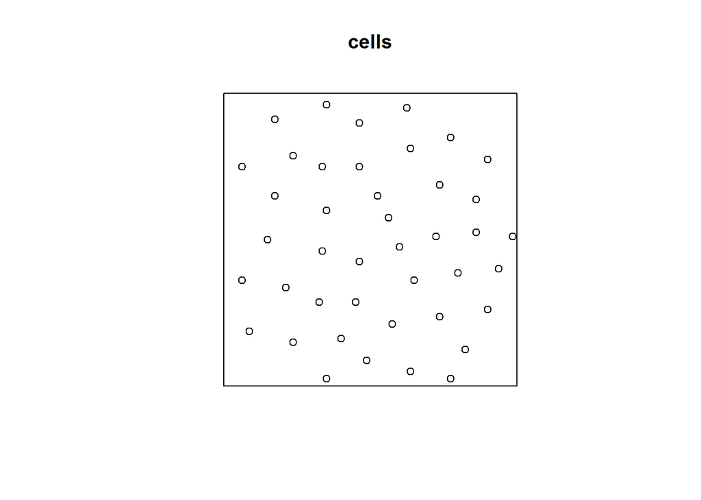

```r
plot(cells)
```

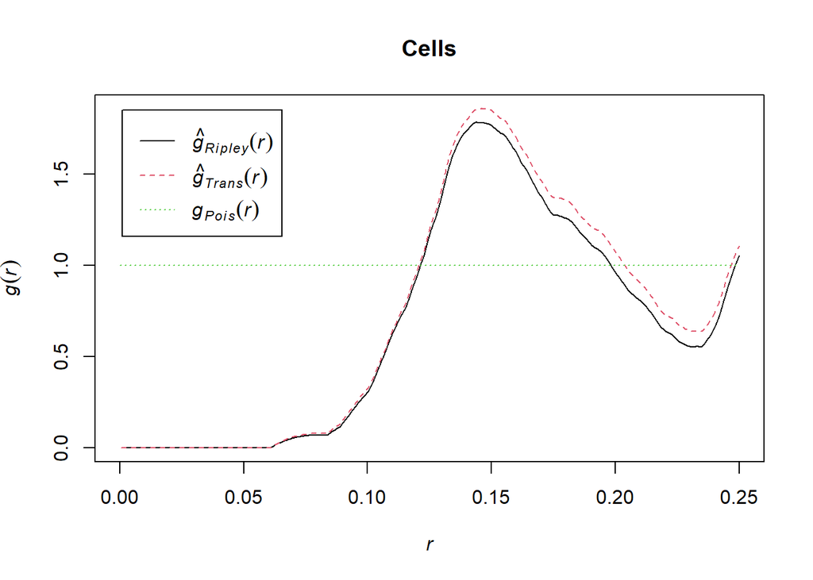

```r
plot(pcf(cells),main="Cells")
```

```
## Generating 39 simulations of CSR  ...
## 1, 2, 3, 4, 5, 6, 7, 8, 9, 10, 11, 12, 13, 14, 15, 16, 17, 18, 19, 20, 21, 22, 23, 24, 25, 26, 27, 28, 29, 30, 31, 32, 33, 34, 35, 36, 37, 38,  39.
##
## Done.
```

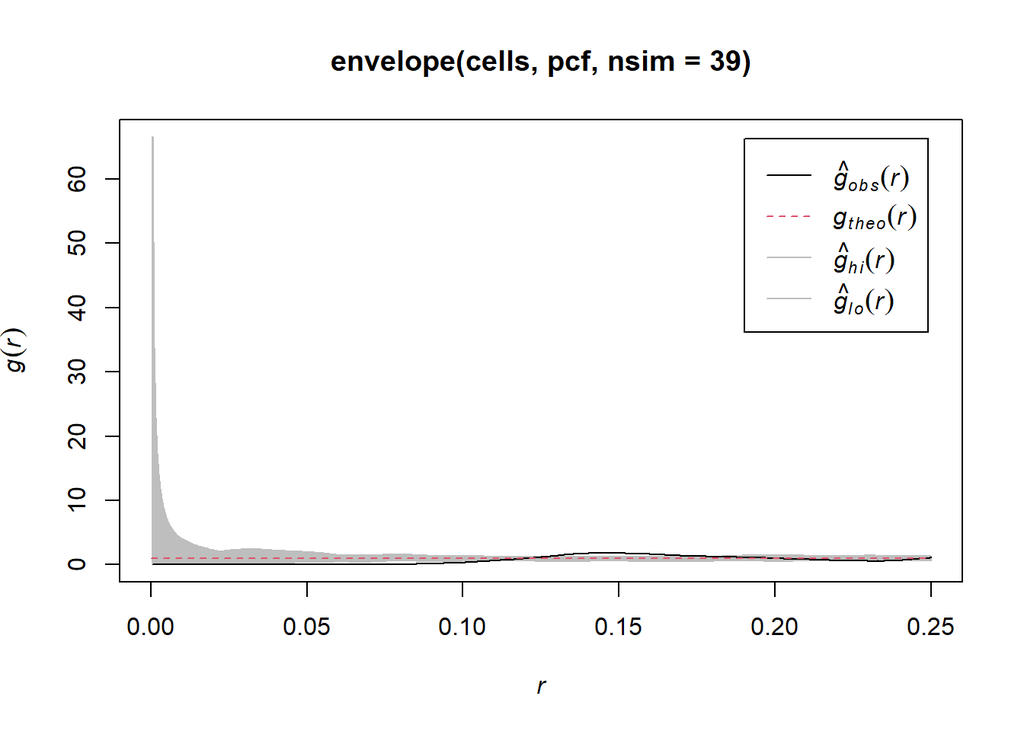

```r
plot(envelope(cells, pcf, nsim=39))
```

What do we see here? The PCF deviates from CSR at shorter distances, indicating it is more dispersed than we should expect. At longer distances (~0.15) the data again go outside the envelope but this time with higher values of *g*, suggesting clustering at this scale. But since we simulated the random processes we see the range of CSR outcomes. The fact that the cells data strays outside this envelope lends support that there is some clustering and dispersion at some distances, but this is not significant at *all* distances.

Now let’s return to our data gorilla nest data and run a couple of these.

```
## Generating 39 simulations of CSR  ...
## 1, 2, 3, 4, 5, 6, 7, 8, 9, 10, 11, 12, 13, 14, 15, 16, 17, 18, 19, 20, 21, 22, 23, 24, 25, 26, 27, 28, 29, 30, 31, 32, 33, 34, 35, 36, 37, 38,  39.
##
## Done.
```

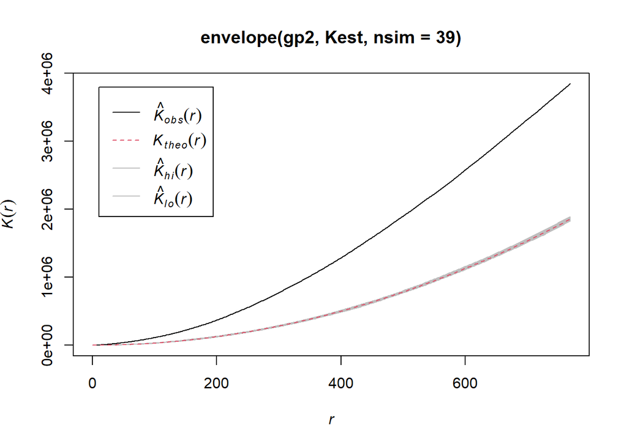

```r
plot(envelope(gp2, Kest, nsim=39))
```

```
## Generating 39 simulations of CSR  ...
## 1, 2, 3, 4, 5, 6, 7, 8, 9, 10, 11, 12, 13, 14, 15, 16, 17, 18, 19, 20, 21, 22, 23, 24, 25, 26, 27, 28, 29, 30, 31, 32, 33, 34, 35, 36, 37, 38,  39.
##
## Done.
```

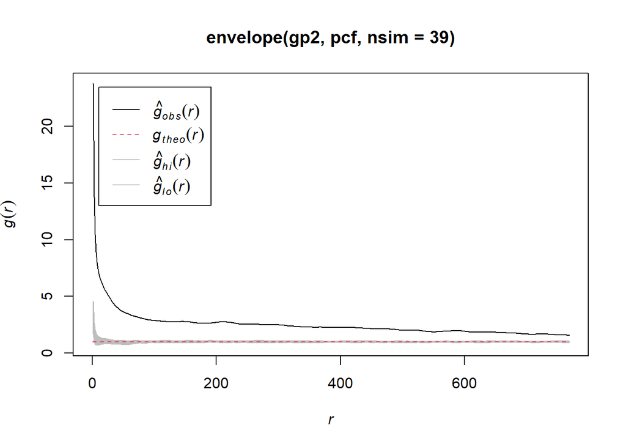

```r
plot(envelope(gp2, pcf, nsim=39))
```

As you can see, the CSR simulation doesn’t affect our outcomes very much. Within the space of the sanctuary, the gorilla nests are found to be pretty clustered spatially. This could be shaped by external factors, such as threats or resource availability. It could also be a function of intergroup dynamics. Or it could be a combination of these. Next time, we will look at how we can use these methods to assess these different kinds of spatial proceses.

# Bringing it all together

OK, now we have these methods in our toolkit, let’s look again at the Makiloa dataset. This time, in addition to the boundary and primary features, load in the secondary features as well. *Plot the primary and secondary features on the boundary data using `ggplot2`. Give the primary and secondary features different colors, but no need to color them by attribute.* What we would like to know is whether we can detect significant differences in clustering/dispersal of features. Using `Gest`, `Kest`, and `pcf`, analyze these against simulated CSR using `envelope`. Plot the outcomes.